# Revisiting a meta-analysis of caregiver training studies: Using machine learning to identify moderators

Caspar J. van Lissa

1

September 14, 2018

## Introduction

Secondary analysis of [Fukkink & Lont, 2007](http://spinusa.net/Does%20Training%20Matter_2007_Fukkink.pdf):

A meta-analysis on the effect of training on caregiver competency

Goals of meta-analysis:

1. Summarize (quasi-)experimental studies of caregiver training
2. **What study characteristics are associated with training efficacy?**

Thus: Moderator analysis was an explicit goal of the original work

## The problem with moderators

Meta-analysis intended to summarize highly similar studies

Often **(ab?)used** to summarize diverse bodies of literature

Differences between studies can be coded as moderators and controlled using meta-regression

Problem with meta-regression:

- Lacks power to identify relevant moderators
- Overfitting when the number of studies is not **much larger** than the number of moderators
- And just forget about including interactions!

**Fukkink & Lont coded 28 moderators, for 17 studies**

## A solution: Metaforest

Metaforest: Identifying relevant moderators in meta-analysis using the machine learning algorithm *random forests*  
[R-package: Van Lissa, 2017](https://cran.r-project.org/package=metaforest)

[Validation study: Van Lissa, 2017](https://osf.io/khjgb/)

Advantages:

- Simulations show high power with as few as 20 effect sizes
- Controls overfitting
- Accounts for interactions and non-linear effects

## Description of the data

Search terms:

- train*, instruct*, educat*, prepar*, experiment*
- childcare, early childhood, preschool, caregiver*, teacher*

Studies published between 1980 and 2005

Databases:

- ERIC
- PsychINFO
- SSCI
- Gray literature
- Backward search by author names

Found 17 unique samples, yielding 78 effect sizes (Hedges’ G)

## Descriptive statistics

Observed effect sizes ranged from -0.89 to 2.02  
$M_g = 0.46$, $SD = 0.58$

Sample sizes ranged from 16 to 207  
$M_n = 58.82$, $SD = 54.17$

Several studies reported multiple effect sizes (1 to 10)

## Replicating the original meta-analysis

Multilevel meta-analysis for dependent effect sizes  
(Van den Noortgate et al., 2013)

**Overall effect size:**

$\hat{\gamma} = 0.45$, 95% CI [0.25, 0.65]

**Tests for residual heterogeneity**

- $Q(77) = 284.46, p < 0.01$
- Total $I^2 = 76.58\%$
- Between studies: $I^2_b = 40.57\%$, $\sigma^2_b = 0.12$, 95% CI [0.04, 0.35]
- Within studies: $I^2_w = 36.01\%$, $\sigma^2_w = 0.11$, 95% CI [0.05, 0.20]

The overall effect size exactly replicates the findngs in the paper.

## Publication bias

[interactive chart not shown]

Some evidence for publication bias:

Funnel plot asymmetry test: $z = 4.08, p < 0.01$

File drawer analysis indicated that $K = 3533$ studies averaging null-results would have to be added to render the summary effect non-significant

# Moderator analyses

## Original moderator analyses

Original paper describes two approaches for determining important moderators:

1. “All at once”: A multivariate meta-regression model with several pre-selected moderators
2. “One at a time”: Univariate meta-regression analyses for each moderator

We compared these methods against MetaForest

## Multilevel data solution

When dealing with multilevel data:

- Clustered bootstrapping of dependent effect sizes
- Unbiased prediction error:
  - Two parallel forests (10.000 trees)
  - Cross-predictions
  - [Janitza, Celik, & Boulesteix, 2016](https://doi.org/10.1007/s11634-016-0276-4)

## Recursive pre-selection algorithm for p >> N

**Problem:** Very large number of potential moderators (28)

**Solution:** Recursive pre-selection; 100 replications

Algorithm:

1. Start with all moderators
2. Conduct random-effects metaforest, with 2000 trees
3. **If** no moderators have negative importance values, or only one moderator, return the resulting model  
   **Else**, drop the variable with most negative variable importance, go back to Step 2

Moderators selected in 30%+ of replications are retained for further analysis

## Recursive pre-selection results

[interactive chart not shown]

## Model tuning and cross-validation

Goal: Finding optimal settings for MetaForest analysis

- 10-fold (clustered) cross-validation
- Settings considered:
  - Weights (“random”, “fixed”, “uniform”),
  - Candidate variables (2, 4, 6)
  - Min. node size = (2, 4, 6)
- Select model with smallest prediction error (RMSE)

Optimal model: fixed weights, 2 candidate variables, min node size 6

## Results

Cross-validated $R^2_{cv} = 0.14$

Clear evidence of model convergence:

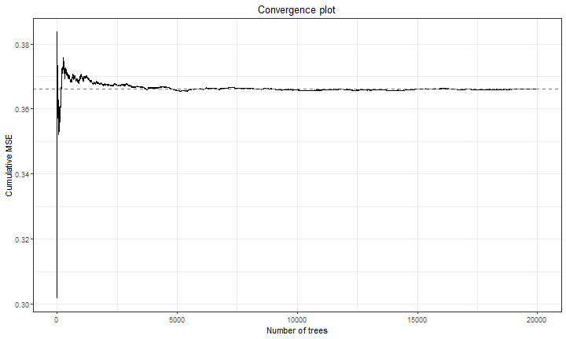

## Variable importance

Contribution to predictive performance; encompasses interactions/non-linear effects

[interactive chart not shown]

## Difference with original paper

Approaches compared:

1. “All at once”: A multivariate meta-regression model with multiple pre-selected moderators
2. “One at a time”: Univariate meta-regression analyses for each moderator
3. “MF”: MetaForest analysis

Variable importance is defined as:

- Effect size ($\beta$) for regression
- Permutation importance for metaforest

For the sake of making visual comparisons, (absolute) variable importance was rescaled to percentage-of-maximum

[interactive chart not shown]

## Comparing approaches

**Variables selected by all approaches:**

The fact that these variables were selected in all approaches suggests that these findings are reliable and likely to generalize to new studies/trainings

- DV_Alligned; whether the dependent variable matched the content of the training
- Location; whether the training was implemented across many sites or in one care center
- Curriculum; whether the training followed a fixed curriculum

**Variables only selected by meta-regression:**

The fact that these variables were **not** selected by MetaForest suggests that the pattern in the data does not hold up to bagging and cross-validation. In other words, meta-regression might be capturing noise caused by a few outliers

- Journal; whether the study was published in an academic journal
- DV_Skills; whether the dependent variable assessed skills

**Variables only selected by MetaForest:**

The fact that these variables were **not** selected by meta-regression suggests that this analysis lacks power, or that the effects of these variables are non-linear or interactive

- Final_N_exp and n_total; number of participants in the experimental condition and in total
  - Marginal association plots suggest a non-linear effect: Very small studies tend to have larger effect sizes
- Pretest_es; effect size at pretest
  - Marginal association plots suggest a non-linear effect: Studies with a positive ES at pre-test tend to have a larger ES at post-test, as well
- Several other variables were selected, but their variable importance was infinitessimal

## Bivariate marginal association plots 1/2

“Main effects” of each moderator, averaging over all values of the other moderators

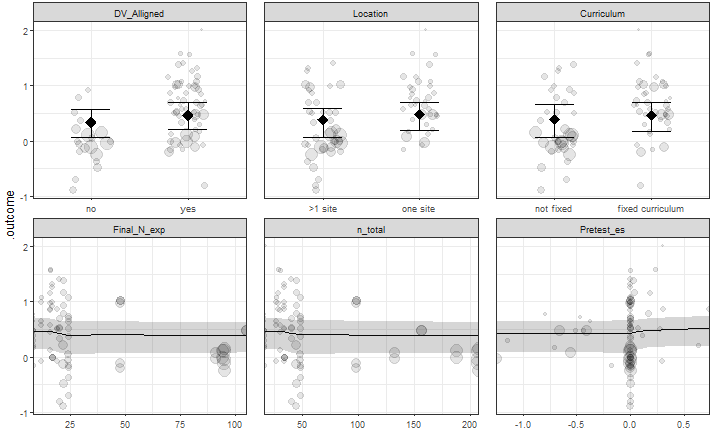

## Bivariate marginal association plots 2/2

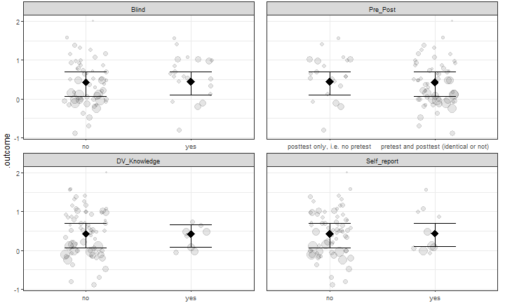

## Conclusions

MetaForest has an advantage at weeding out relevant moderators, and controls for overfitting

This advantage was especially obvious for continuous moderators with non-linear effects

Of course, binary moderators have a linear effect by definition